# Brazil dengue: how much of the clustering is the prior?

ddCRP decay scale and distance metric sensitivity, Paraná 2024

17 September 2026

# 1 What this study varies, and what it holds fixed

The dengue application in `src/run_dengue.jl` fits

$$y_i \mid \rho_k, r_k \sim
\text{NegBin}\!\left(\text{mean} = E_i \rho_k,\; \text{size} =
r_k\right)$$

to the 399 municipalities of Paraná, with a ddCRP prior over the partition. That prior has two ingredients we chose rather than estimated: a **decay scale** `s`, fixed at 0.5, and a **distance metric**, the great-circle distance between municipality centroids. This report asks how much of the fitted clustering survives changing them.

The likelihood, the priors on $\rho$ and $r$, the proposal families, the proposal scales and the random seed are **identical across every configuration below**. Only the ddCRP prior moves. Anything that changes is therefore attributable to the prior, not to the sampler.

## 1.1 The decay scale is a rate, not a length

This is the single easiest thing to read backwards. The package defines

$$\Pr(c_i = j) \;\propto\; \exp(-d_{ij}\,
s), \qquad j \neq i,$$

so `s` multiplies the distance. **Larger `s` means faster decay and a more local prior.** (The hop metric is the one exception: there `s` is a window radius in hops, described below.) The decay length in kilometres is `D_scale / s`, so `s = 0.5` on distances rescaled by the 232 km median pairwise separation is a decay length of about 463 km, and `s = 10` is about 23 km. In the flat limit `s = 0.0001` every pair has weight within $10^{-4}$ of 1 and the ddCRP degenerates into a plain, distance-independent CRP. That limit is the natural null: if the clustering at `s = 0.5` looks like the clustering at `s = 0.0001`, the spatial prior is not doing any work.

## 1.2 The configurations

Every configuration. The sampler is identical throughout.

| config | metric | what the metric is | s | iterations | burn-in | thin |
| --- | --- | --- | --- | --- | --- | --- |
| geodesic__s0p0001 | geodesic | great-circle distance between municipality centroids | 0.0001 | 40000 | 10000 | 5 |
| geodesic__s0p01 | geodesic | great-circle distance between municipality centroids | 0.0100 | 40000 | 10000 | 5 |
| geodesic__s0p1 | geodesic | great-circle distance between municipality centroids | 0.1000 | 40000 | 10000 | 5 |
| geodesic__s0p5 | geodesic | great-circle distance between municipality centroids | 0.5000 | 40000 | 10000 | 5 |
| geodesic__s1 | geodesic | great-circle distance between municipality centroids | 1.0000 | 40000 | 10000 | 5 |
| geodesic__s5 | geodesic | great-circle distance between municipality centroids | 5.0000 | 40000 | 10000 | 5 |
| geodesic__s10 | geodesic | great-circle distance between municipality centroids | 10.0000 | 40000 | 10000 | 5 |
| geodesic__infer_s | geodesic | great-circle distance between municipality centroids | inferred | 40000 | 10000 | 5 |
| hop__s1 | hop | uniform link weight within s graph hops, suppressed beyond | 1.0000 | 40000 | 10000 | 5 |
| hop__s2 | hop | uniform link weight within s graph hops, suppressed beyond | 2.0000 | 40000 | 10000 | 5 |
| hop__s3 | hop | uniform link weight within s graph hops, suppressed beyond | 3.0000 | 40000 | 10000 | 5 |
| hop__s4 | hop | uniform link weight within s graph hops, suppressed beyond | 4.0000 | 40000 | 10000 | 5 |
| hop__s5 | hop | uniform link weight within s graph hops, suppressed beyond | 5.0000 | 40000 | 10000 | 5 |
| comm_dist__s0p1 | comm_dist | communicability distance sqrt(G_ii + G_jj - 2 G_ij), G = exp(A) | 0.1000 | 40000 | 10000 | 5 |
| comm_dist__s0p5 | comm_dist | communicability distance sqrt(G_ii + G_jj - 2 G_ij), G = exp(A) | 0.5000 | 40000 | 10000 | 5 |
| comm_dist__s5 | comm_dist | communicability distance sqrt(G_ii + G_jj - 2 G_ij), G = exp(A) | 5.0000 | 40000 | 10000 | 5 |
| log_comm__s0p1 | log_comm | -log(G_ij / max G), G = exp(A); link weight proportional to G_ij^s | 0.1000 | 40000 | 10000 | 5 |
| log_comm__s0p5 | log_comm | -log(G_ij / max G), G = exp(A); link weight proportional to G_ij^s | 0.5000 | 40000 | 10000 | 5 |
| log_comm__s5 | log_comm | -log(G_ij / max G), G = exp(A); link weight proportional to G_ij^s | 5.0000 | 40000 | 10000 | 5 |

# 2 The data

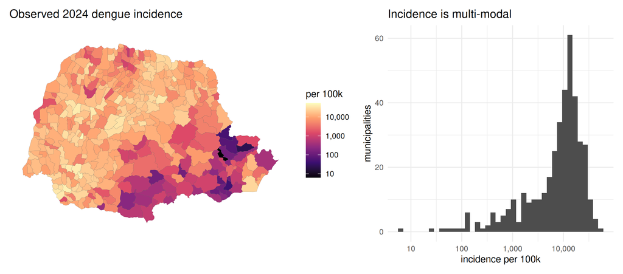

# 3 The distance metrics

Municipalities are areal units, not points, so centroid distance is only one reasonable prior geometry. Three alternatives are included here, all built from the queen contiguity graph $A$ (two municipalities are adjacent if their boundaries touch).

The contiguity graph has 1110 edges, mean degree 5.56 and diameter 21 hops. The geodesic and communicability metrics are rescaled by their own median off-diagonal entry, so a given s means the same decay per median separation under each; the hop rows are 0 / 30 window matrices and s is their radius.

| metric | s | what it is | median raw scale | max / median | pairs inside window |
| --- | --- | --- | --- | --- | --- |
| geodesic |  | great-circle distance between municipality centroids | 231.700 | 2.72 | 100.0% |
| comm_dist |  | communicability distance sqrt(G_ii + G_jj - 2 G_ij), G = exp(A) | 6.136 | 1.78 | 100.0% |
| log_comm |  | -log(G_ij / max G), G = exp(A); link weight proportional to G_ij^s | 9.737 | 3.70 | 100.0% |
| hop | 1 | uniform link weight within s graph hops, suppressed beyond | 1.000 | 30.00 | 1.4% |
| hop | 2 | uniform link weight within s graph hops, suppressed beyond | 1.000 | 30.00 | 4.5% |
| hop | 3 | uniform link weight within s graph hops, suppressed beyond | 1.000 | 30.00 | 9.4% |
| hop | 4 | uniform link weight within s graph hops, suppressed beyond | 1.000 | 30.00 | 15.9% |
| hop | 5 | uniform link weight within s graph hops, suppressed beyond | 1.000 | 30.00 | 23.6% |

**Communicability.** $G = \exp(A)$ counts walks of every length between two nodes, discounted by $1/\ell!$, so it is the graph analogue of a diffusion kernel. Two readings of it appear here. `comm_dist` is the communicability distance $\xi_{ij} = \sqrt{G_{ii} + G_{jj} - 2G_{ij}}$, a genuine metric that drops straight into $\exp(-sd)$. `log_comm` is $-\log(G_{ij}/\max G)$, which makes the ddCRP link weight proportional to $G_{ij}^{\,s}$, the most direct reading of “use $\exp(A)$ as the kernel”.

**Hop windows.** For `hop`, **`s` is the window radius in graph hops**, not a rate: every municipality within `s` edges of $i$ is an equally likely link target, and every one beyond is suppressed. Larger `s` is therefore a *less* local prior, the opposite direction to every other metric. The window is the whole of the prior’s spatial content; a decay rate inside it was dropped because the inferred concentration $\alpha$ absorbs almost all of it. A link weight of exactly zero would put $-\infty$ into the log-posterior and NaN into the Metropolis ratio, so the suppression is a soft floor: in-window pairs have distance 0 and excluded pairs distance 30 under a kernel rate of 1, making them $e^{-30} \approx 9\times10^{-14}$ times weaker. The window is effectively hard while every log-weight stays finite.

## 3.1 How the metrics relate to one another

[figure not shown]

Hop distance tracks kilometres closely, as it must in a state with no islands and fairly even municipality sizes, but with substantial spread: two municipalities 100 km apart can be anywhere from 2 to 8 hops away depending on how finely the intervening land is subdivided. That spread is exactly what makes the hop metrics a genuinely different prior rather than a reparameterisation.

## 3.2 What each prior lets one municipality link to

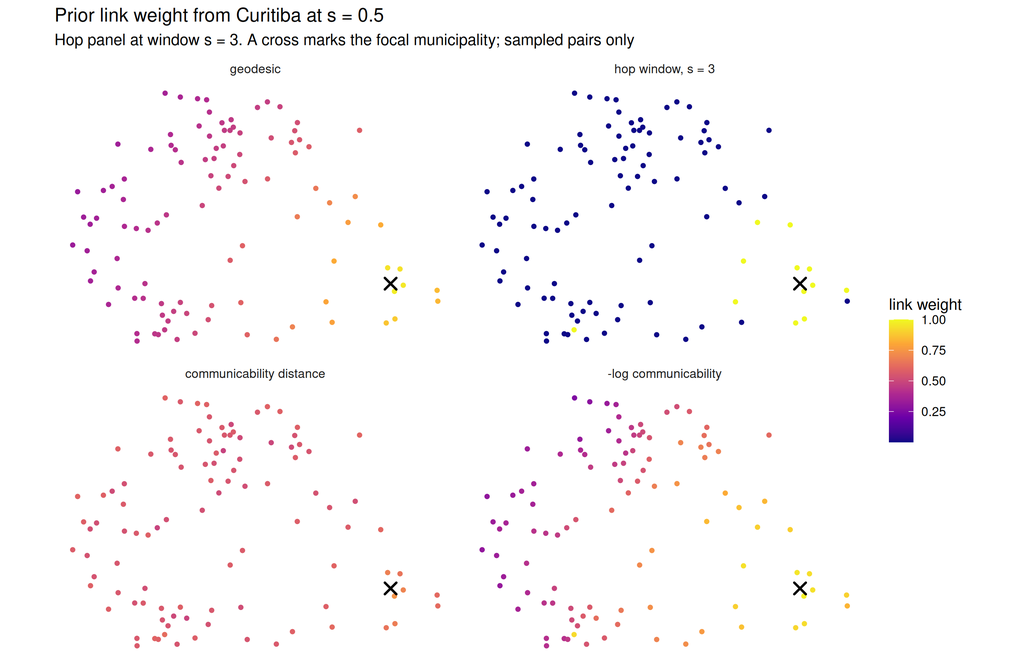

One thing that panel makes plain: **the communicability distance is nearly flat beyond the first ring of neighbours.** Its central 90% of pairs spans only 0.63 in rescaled units, against 1.65 for great-circle distance and 1.50 for hop distance. The reason is structural: $G_{ii}$ dominates $G_{ij}$ for all but immediate neighbours, so $\xi_{ij} = \sqrt{G_{ii} + G_{jj} - 2G_{ij}}$ flattens out almost immediately. Under $\exp(-sd)$ that makes it behave much like the flat limit, and its fitted $K$ should be read against `s` near zero rather than against the other metrics. `log_comm` does not have this problem, because taking a logarithm restores the dynamic range.

# 4 MCMC diagnostics

Everything below is read off chains that were burnt in and thinned before being written, so no further burn-in is applied here.

Mixing and acceptance by configuration.

| config | mean K | mode K | sd K | ESS(K) | ESS(logpost) | ESS rho | ESS r | birth % | death % | fixed % | ESJD(K) | time (s) |
| --- | --- | --- | --- | --- | --- | --- | --- | --- | --- | --- | --- | --- |
| geodesic s=0.0001 | 12.62 | 6 | 7.00 | 18 | 16 | 73 | 75 | 8.70 | 3.86 | 36.30 | 4.209 | 2472 |
| geodesic s=0.0100 | 6.83 | 3 | 4.02 | 53 | 16 | 56 | 63 | 7.67 | 4.72 | 44.18 | 3.371 | 2662 |
| geodesic s=0.1000 | 19.14 | 8 | 13.22 | 17 | 18 | 90 | 55 | 8.88 | 3.57 | 37.72 | 4.775 | 2412 |
| geodesic s=0.5000 | 14.04 | 8 | 8.16 | 47 | 50 | 128 | 143 | 8.57 | 4.12 | 38.99 | 4.337 | 2455 |
| geodesic s=1.0000 | 15.77 | 12 | 8.48 | 11 | 23 | 108 | 37 | 8.69 | 3.61 | 31.67 | 4.298 | 2291 |
| geodesic s=5.0000 | 17.23 | 12 | 7.03 | 33 | 34 | 69 | 99 | 7.89 | 1.76 | 7.93 | 4.011 | 2300 |
| geodesic s=10.0000 | 22.02 | 20 | 5.53 | 24 | 19 | 43 | 64 | 7.54 | 0.76 | 3.32 | 3.171 | 1816 |
| geodesic (s inferred) | 28.79 | 27 | 6.30 | 23 | 11 | 53 | 64 | 7.69 | 0.54 | 3.60 | 2.695 | 1311 |
| hop s=1 hop | 39.72 | 39 | 4.00 | 51 | 52 | 36 | 57 | 3.63 | 0.13 | 0.87 | 1.018 | 1076 |
| hop s=2 hops | 24.17 | 23 | 4.28 | 46 | 54 | 32 | 59 | 5.14 | 0.40 | 2.25 | 2.032 | 1341 |
| hop s=3 hops | 21.53 | 15 | 7.26 | 21 | 24 | 46 | 61 | 6.00 | 0.88 | 4.32 | 3.270 | 1646 |
| hop s=4 hops | 16.84 | 16 | 6.43 | 29 | 34 | 43 | 58 | 6.13 | 1.29 | 6.72 | 3.550 | 1704 |
| hop s=5 hops | 22.42 | 22 | 8.88 | 25 | 34 | 57 | 72 | 7.34 | 1.66 | 8.92 | 4.411 | 1697 |
| comm_dist s=0.1000 | 7.76 | 4 | 4.96 | 36 | 62 | 52 | 53 | 7.52 | 4.47 | 42.61 | 3.477 | 2857 |
| comm_dist s=0.5000 | 7.35 | 3 | 4.85 | 34 | 16 | 44 | 50 | 7.86 | 4.67 | 42.74 | 3.395 | 2839 |
| comm_dist s=5.0000 | 12.62 | 8 | 5.75 | 46 | 16 | 72 | 47 | 8.08 | 2.37 | 16.51 | 3.588 | 2358 |
| log_comm s=0.1000 | 9.60 | 4 | 6.86 | 35 | 54 | 66 | 76 | 8.34 | 4.26 | 38.73 | 3.570 | 2875 |
| log_comm s=0.5000 | 13.46 | 10 | 7.41 | 24 | 35 | 112 | 90 | 8.74 | 4.27 | 35.70 | 4.491 | 2539 |
| log_comm s=5.0000 | 17.32 | 10 | 8.11 | 18 | 14 | 57 | 67 | 7.77 | 1.82 | 8.16 | 4.090 | 1941 |

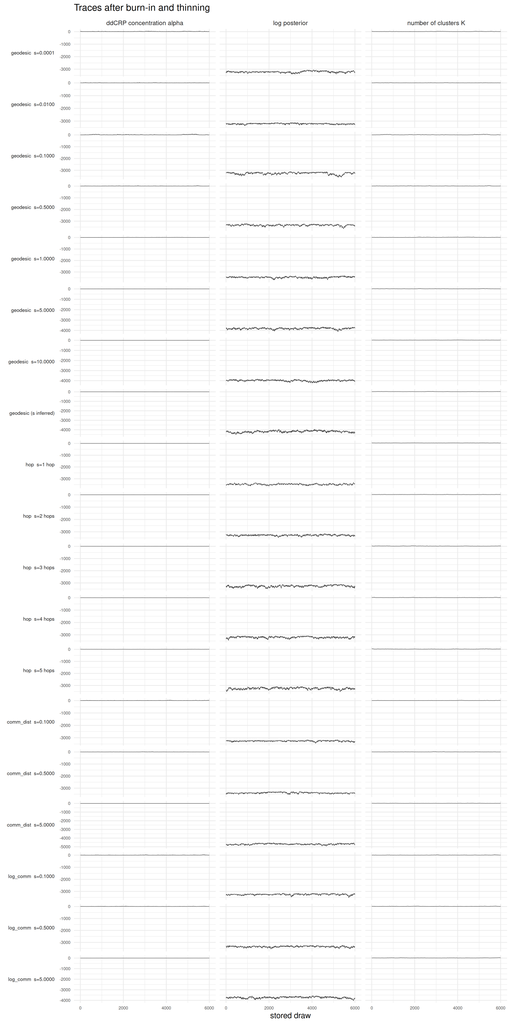

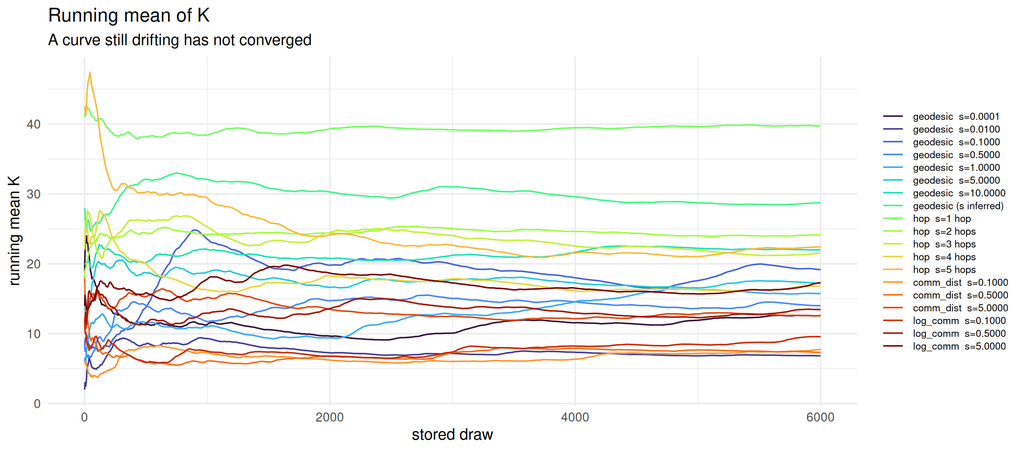

# 5 The posterior of the number of clusters

$K$ is a count, so its posterior is drawn as bars rather than a line.

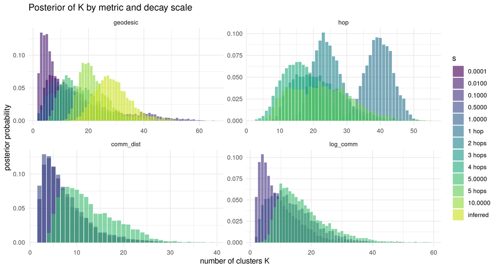

# 6 Sensitivity to the decay scale

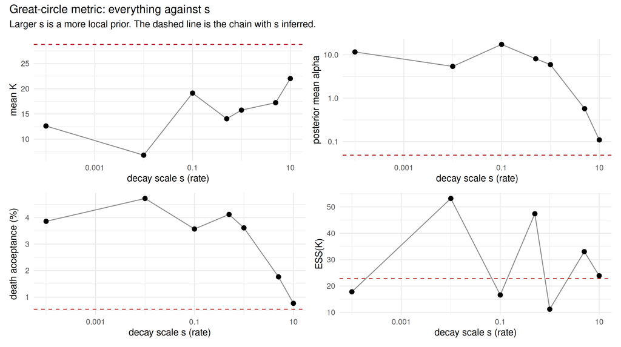

Across `s` from 0.0001 to 10, mean $K$ moves from 12.6 to 22.0 and the posterior mean of the ddCRP concentration $\alpha$ from 11.63 to 0.11. The two move in opposite directions by construction: a more local prior makes distant links unlikely, so more clusters form, and the self-link weight $\alpha$ needed to explain them falls.

The chain that infers `s` settles at `s` = 15.54 with $\alpha$ = 0.049 and mean $K$ = 28.8, and its death acceptance is 0.54%. That is the degeneracy `run_dengue.jl` documents: left free, `s` runs towards a strongly local kernel where death moves almost never succeed, which is why the application fixes it.

# 7 The alternative metrics

[figure not shown]

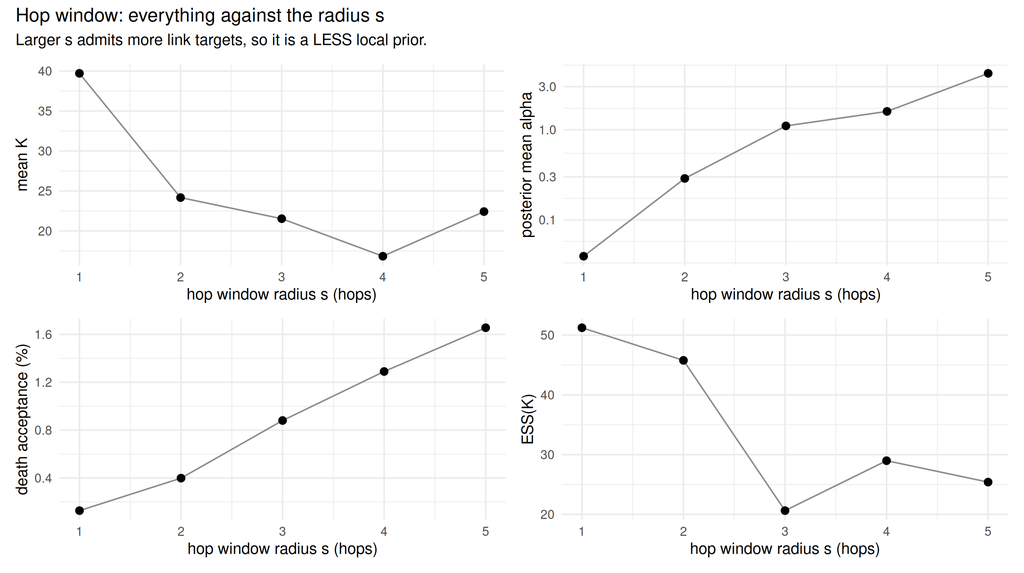

At the shared scale `s = 0.5`, mean $K$ ranges from 14.0 under `geodesic` to 7.3 under `comm_dist`.

The hop windows are the extreme case. Widening the window from 1 to 5 hops moves mean $K$ from 39.7 to 22.4: restricting links to immediate neighbours forbids the long-range links that let a cluster span the state, so the partition fragments and death moves become very hard to accept.

# 8 The fitted partitions

Maps use the **mode partition**: the highest log-posterior draw among those whose cluster count equals the posterior mode of $K$. The Dahl least-squares partition is also in the exported table, but it over-fragments here because the co-clustering signal is weak, and its $K$ would not match the $K$ reported everywhere else.

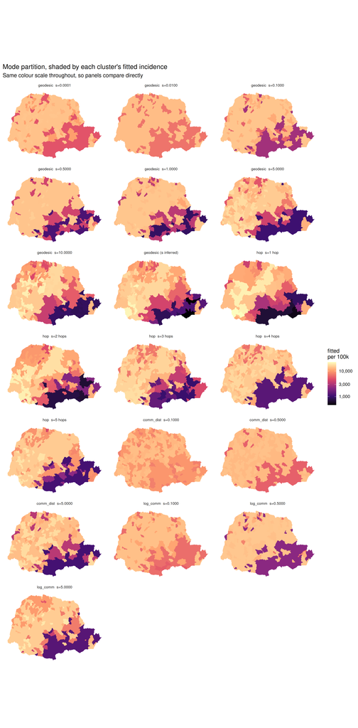

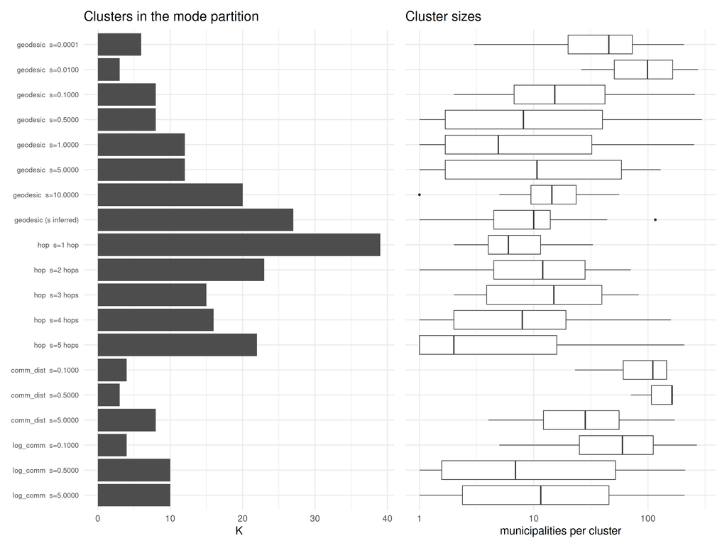

# 9 Do the configurations agree with each other?

This is the question the whole study is built around. There is no ground truth on real data, so agreement between partitions fitted under genuinely different priors is what stands in for one. High agreement means the clustering is a property of the data; low agreement means it is a property of the prior.

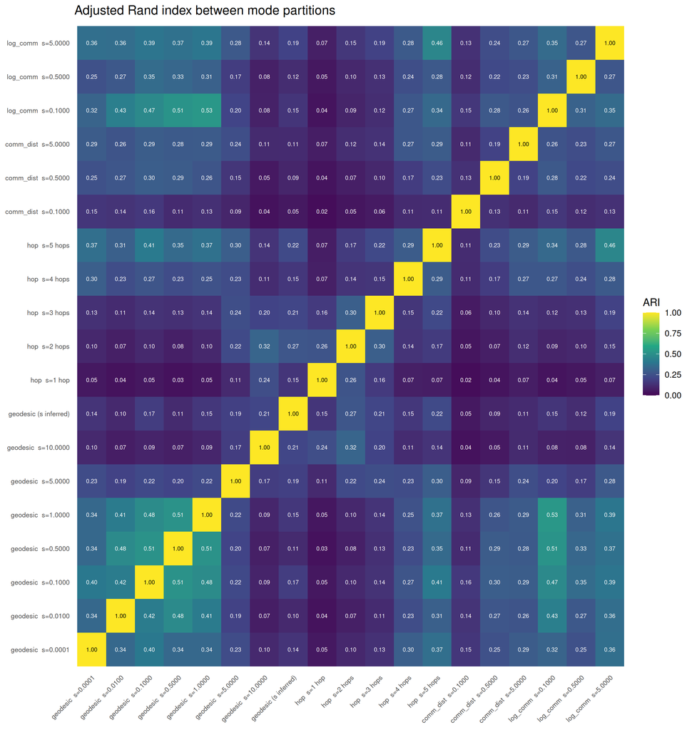

Off-diagonal ARI runs from 0.02 to 0.53, median 0.19. The closest pair is `geodesic__s1` against `log_comm__s0p1` (0.53); the furthest is `comm_dist__s0p1` against `hop__s1` (0.02).

# 10 Model comparison

WAIC, LPML and PSIS-LOO score how well each fit predicts the observed counts. They are comparable across configurations here because the likelihood is identical and only the prior over partitions differs. `k>0.7` counts the observations whose Pareto-smoothed importance weights are unreliable; a large count means the LOO column should be read with caution and WAIC or LPML preferred.

Predictive scores, best WAIC first.

| config | WAIC | dWAIC | p_WAIC | LPML | elpd_loo | k>0.7 |
| --- | --- | --- | --- | --- | --- | --- |
| hop s=1 hop | 6072.3 | 0.0 | 101.0 | -3056.8 | -3044.9 | 0 |
| hop s=2 hops | 6080.9 | 8.6 | 109.1 | -3063.1 | -3049.6 | 0 |
| geodesic s=10.0000 | 6091.9 | 19.6 | 124.3 | -3070.1 | -3056.2 | 0 |
| geodesic (s inferred) | 6096.1 | 23.8 | 114.7 | -3071.2 | -3057.4 | 0 |
| comm_dist s=5.0000 | 6113.0 | 40.8 | 144.5 | -3119.1 | -3084.1 | 0 |
| geodesic s=5.0000 | 6132.7 | 60.5 | 126.3 | -3096.1 | -3078.7 | 0 |
| hop s=3 hops | 6138.6 | 66.3 | 116.2 | -3098.9 | -3082.7 | 0 |
| log_comm s=5.0000 | 6143.3 | 71.0 | 125.4 | -3105.6 | -3085.8 | 0 |
| hop s=4 hops | 6146.2 | 73.9 | 116.4 | -3105.2 | -3085.2 | 0 |
| hop s=5 hops | 6155.7 | 83.4 | 131.6 | -3105.3 | -3088.0 | 0 |
| geodesic s=1.0000 | 6201.8 | 129.5 | 134.1 | -3138.3 | -3113.4 | 0 |
| geodesic s=0.5000 | 6228.1 | 155.8 | 120.9 | -3164.8 | -3132.0 | 0 |
| log_comm s=0.5000 | 6253.4 | 181.2 | 115.4 | -3187.2 | -3147.7 | 0 |
| geodesic s=0.1000 | 6263.8 | 191.6 | 140.3 | -3187.8 | -3158.6 | 0 |
| geodesic s=0.0001 | 6327.5 | 255.3 | 126.9 | -3206.6 | -3180.2 | 0 |
| comm_dist s=0.5000 | 6356.5 | 284.2 | 107.2 | -3207.9 | -3187.8 | 0 |
| log_comm s=0.1000 | 6358.6 | 286.3 | 114.6 | -3214.7 | -3193.4 | 0 |
| geodesic s=0.0100 | 6376.8 | 304.5 | 98.6 | -3219.0 | -3197.8 | 0 |
| comm_dist s=0.1000 | 6380.5 | 308.2 | 95.8 | -3213.4 | -3194.4 | 0 |

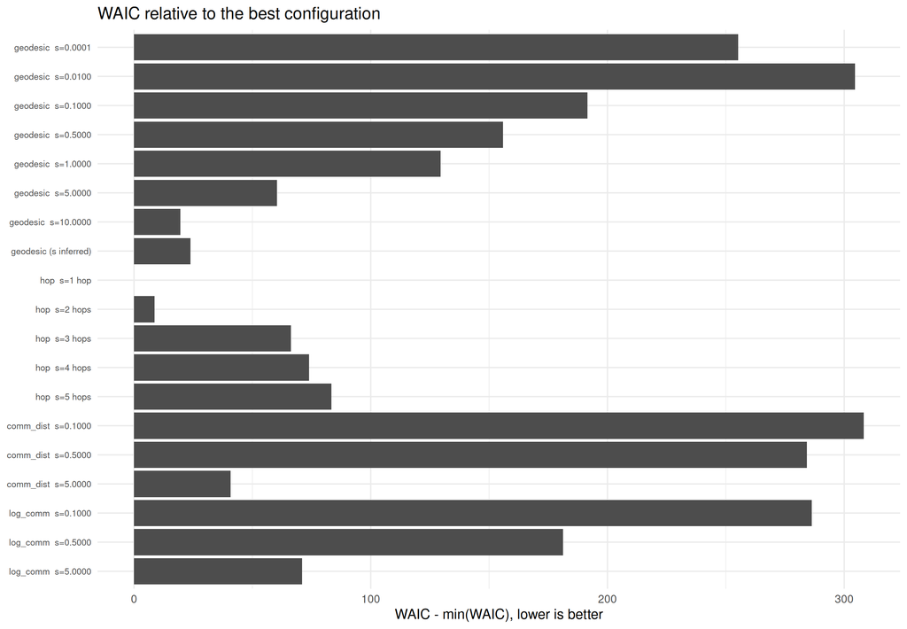

# 11 Posterior predictive checks

Each configuration generated 1,000 replicate datasets from its own posterior. A discrepancy statistic the model cannot reproduce shows up as a posterior predictive p-value near 0 or 1.

Posterior predictive p-values. `misfit` flags ppp outside [0.05, 0.95].

| config | statistic | observed | ppp | replicate median | 2.5% | 97.5% | misfit |
| --- | --- | --- | --- | --- | --- | --- | --- |
| geodesic s=0.0001 | dispersion index Var/Mean | 1.710e+04 | 0.897 | 3.127e+04 | 1.340e+04 | 2.389e+05 |  |
| geodesic s=0.0001 | maximum count | 7.983e+04 | 0.843 | 1.251e+05 | 5.468e+04 | 6.177e+05 |  |
| geodesic s=0.0001 | n municipalities < 100/100k | 6.000e+00 | 0.707 | 7.000e+00 | 2.000e+00 | 1.500e+01 |  |
| geodesic s=0.0001 | 90th pct of incidence | 2.423e+04 | 0.274 | 2.341e+04 | 2.084e+04 | 2.643e+04 |  |
| geodesic s=0.0001 | Moran’s I of log incidence | 6.044e-01 | 0.000 | 1.451e-01 | -2.081e-03 | 3.824e-01 | yes |
| geodesic s=0.0100 | dispersion index Var/Mean | 1.710e+04 | 0.902 | 3.123e+04 | 1.235e+04 | 2.135e+05 |  |
| geodesic s=0.0100 | maximum count | 7.983e+04 | 0.862 | 1.253e+05 | 5.450e+04 | 5.693e+05 |  |
| geodesic s=0.0100 | n municipalities < 100/100k | 6.000e+00 | 0.785 | 8.000e+00 | 2.000e+00 | 1.600e+01 |  |
| geodesic s=0.0100 | 90th pct of incidence | 2.423e+04 | 0.297 | 2.345e+04 | 2.088e+04 | 2.640e+04 |  |
| geodesic s=0.0100 | Moran’s I of log incidence | 6.044e-01 | 0.000 | 7.145e-02 | -1.961e-02 | 2.504e-01 | yes |
| geodesic s=0.1000 | dispersion index Var/Mean | 1.710e+04 | 0.922 | 3.083e+04 | 1.371e+04 | 1.824e+05 |  |
| geodesic s=0.1000 | maximum count | 7.983e+04 | 0.848 | 1.244e+05 | 5.681e+04 | 5.021e+05 |  |
| geodesic s=0.1000 | n municipalities < 100/100k | 6.000e+00 | 0.591 | 6.000e+00 | 2.000e+00 | 1.300e+01 |  |
| geodesic s=0.1000 | 90th pct of incidence | 2.423e+04 | 0.280 | 2.344e+04 | 2.092e+04 | 2.634e+04 |  |
| geodesic s=0.1000 | Moran’s I of log incidence | 6.044e-01 | 0.000 | 2.958e-01 | 1.525e-01 | 4.148e-01 | yes |
| geodesic s=0.5000 | dispersion index Var/Mean | 1.710e+04 | 0.919 | 3.127e+04 | 1.388e+04 | 2.038e+05 |  |
| geodesic s=0.5000 | maximum count | 7.983e+04 | 0.843 | 1.247e+05 | 5.641e+04 | 5.518e+05 |  |
| geodesic s=0.5000 | n municipalities < 100/100k | 6.000e+00 | 0.624 | 6.000e+00 | 2.000e+00 | 1.300e+01 |  |
| geodesic s=0.5000 | 90th pct of incidence | 2.423e+04 | 0.307 | 2.348e+04 | 2.100e+04 | 2.645e+04 |  |
| geodesic s=0.5000 | Moran’s I of log incidence | 6.044e-01 | 0.000 | 3.651e-01 | 2.600e-01 | 4.615e-01 | yes |
| geodesic s=1.0000 | dispersion index Var/Mean | 1.710e+04 | 0.877 | 2.690e+04 | 1.340e+04 | 1.425e+05 |  |
| geodesic s=1.0000 | maximum count | 7.983e+04 | 0.792 | 1.086e+05 | 5.445e+04 | 4.326e+05 |  |
| geodesic s=1.0000 | n municipalities < 100/100k | 6.000e+00 | 0.601 | 6.000e+00 | 2.000e+00 | 1.300e+01 |  |
| geodesic s=1.0000 | 90th pct of incidence | 2.423e+04 | 0.300 | 2.355e+04 | 2.110e+04 | 2.634e+04 |  |
| geodesic s=1.0000 | Moran’s I of log incidence | 6.044e-01 | 0.000 | 4.228e-01 | 2.874e-01 | 5.141e-01 | yes |
| geodesic s=5.0000 | dispersion index Var/Mean | 1.710e+04 | 0.821 | 2.461e+04 | 1.190e+04 | 6.110e+04 |  |
| geodesic s=5.0000 | maximum count | 7.983e+04 | 0.729 | 1.001e+05 | 5.102e+04 | 2.259e+05 |  |
| geodesic s=5.0000 | n municipalities < 100/100k | 6.000e+00 | 0.593 | 6.000e+00 | 2.000e+00 | 1.302e+01 |  |
| geodesic s=5.0000 | 90th pct of incidence | 2.423e+04 | 0.281 | 2.342e+04 | 2.114e+04 | 2.621e+04 |  |
| geodesic s=5.0000 | Moran’s I of log incidence | 6.044e-01 | 0.002 | 4.922e-01 | 3.946e-01 | 5.765e-01 | yes |

[output cut: 65 more lines]

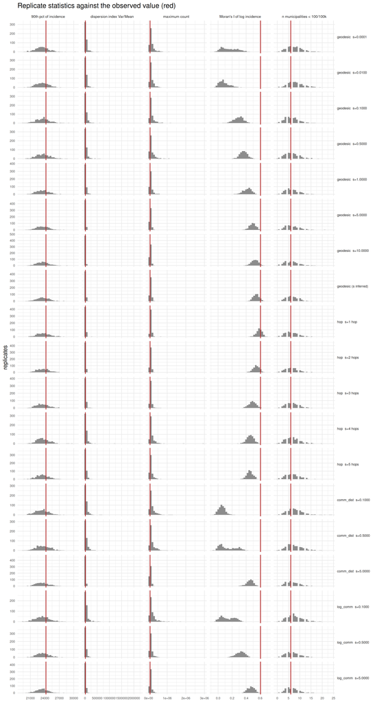

Moran’s I of log incidence is the statistic to watch here, because it is the one the spatial prior is supposed to control. If the fitted clusters reproduce the observed spatial autocorrelation, its p-value sits away from the extremes; if a metric under- or over-smooths, this is where it shows.

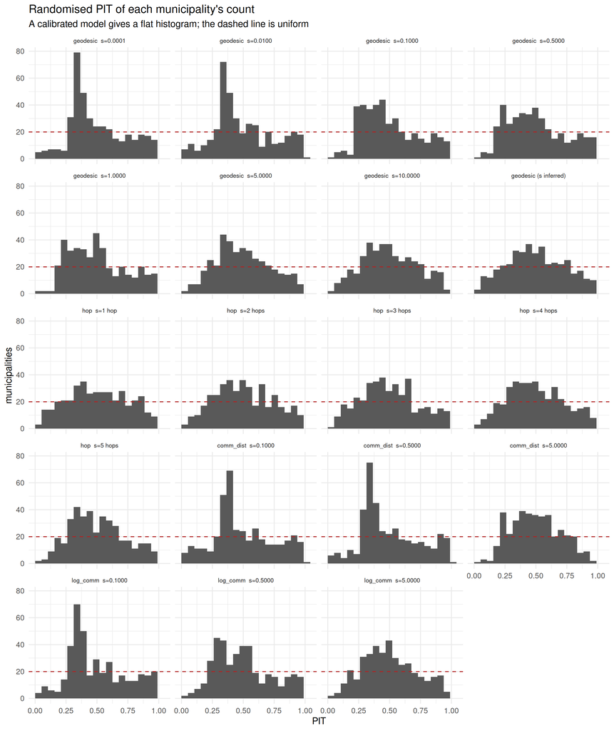

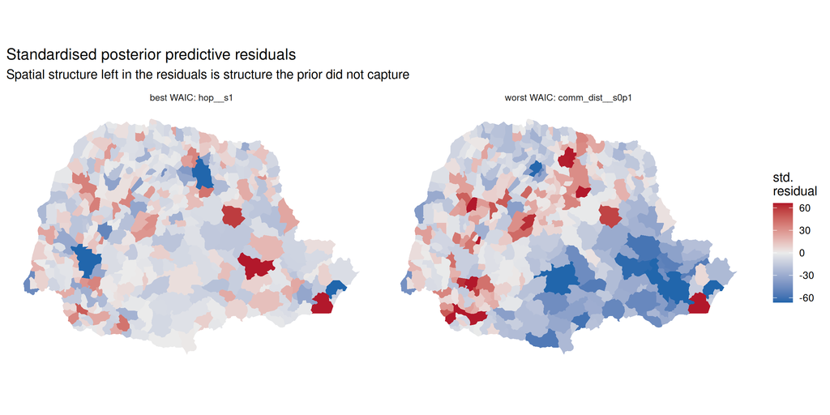

# 12 What to take from this

## 12.1 Caveats

# 13 Reproducing this

```
Rscript src/prepare_dengue_adjacency.R --uf 41
julia --project=. src/dengue_sensitivity.jl --pilot   # measure cost first
julia --project=. src/dengue_sensitivity.jl           # or --slurm
Rscript -e 'rmarkdown::render("src/dengue_sensitivity_analysis.rmd")'
```

Tables read from `/home/marshjs/Documents/Projects/non-conjugate-ddcrp/results/real_data/dengue_sensitivity`:

- `config_index.csv`
- `summary_sensitivity.csv`
- `traces.csv`
- `k_posterior.csv`
- `metric_summary.csv`
- `metric_pairs.csv`
- `cluster_assignments_sensitivity.csv`
- `cross_config_ari.csv`
- `model_comparison.csv`
- `ppc_stats.csv`
- `ppc_replicates.csv`
- `ppc_pointwise.csv`